# lab1

Jake Austin Kistler

2025-09-01

# Tasks

## Task 1

Get the working directory

```r
# Return the wokring dir
getwd()
```

```
## [1] "C:/R_packages/Labs/Lab_1"
```

## Task 2

Get the first 6 rows of data out of DDT.csv

```r
# Read in csv data into data
data <- read.csv("DDT-1.csv")

# display the first 6 rows of this data
head(data,6)
```

```
##   RIVER MILE  SPECIES LENGTH WEIGHT DDT
## 1   FCM    5 CCATFISH   42.5    732  10
## 2   FCM    5 CCATFISH   44.0    795  16
## 3   FCM    5 CCATFISH   41.5    547  23
## 4   FCM    5 CCATFISH   39.0    465  21
## 5   FCM    5 CCATFISH   50.5   1252  50
## 6   FCM    5 CCATFISH   52.0   1255 150
```

## Task 3

Subsetting Data:

Quanitiative values: Mile, Length, Weight and DDT.

Qualititative values: River and Species.

Number of species in data set:

```r
# Return the number of
length(unique(data$SPECIES))
```

```
## [1] 3
```

Number of large mouth bass in sample with weights greater than 800 mg:

```r
# Extract data that has species as large maouth bass and weight greater than 800 mg
large_mouth_base_subset <- data[data$SPECIES == "LMBASS" & data$WEIGHT > 800, ]
# Display the data
large_mouth_base_subset
```

```
##     RIVER MILE SPECIES LENGTH WEIGHT DDT
## 141   TRM  345  LMBASS     30    856 2.2
## 144   TRM  345  LMBASS     36   1433 1.9
```

Number of fish present in sample that came from the SMC river and had DDT values greater that 4.0:

```r
# Extract the data that has river of SCM and DDT values greater than 4.0
ddt_and_SMC_river <- data[data$RIVER == "SCM" & data$DDT > 4.0, ]
# Display the data
ddt_and_SMC_river
```

```
##    RIVER MILE  SPECIES LENGTH WEIGHT DDT
## 16   SCM    1 CCATFISH     45    984 9.1
## 17   SCM    1 CCATFISH     43    965 7.8
## 18   SCM    1 CCATFISH     45   1084 4.1
```

## Task 4

The mean (average) length of the fish in this data set:

```r
# Calculate and display the mean length of the fish in the data set
mean(data$LENGTH)
```

```
## [1] 42.8125
```

The standard deviation of the weight of the data set:

```r
# Calculate and display the standard div of the weight of the fish in the data set
sd(data$WEIGHT)
```

```
## [1] 376.5461
```

From the given picture we can recreate both potinal plots (WEIGHT vs LENGTH or LENGTH vs WEIGHT) to answer the question.

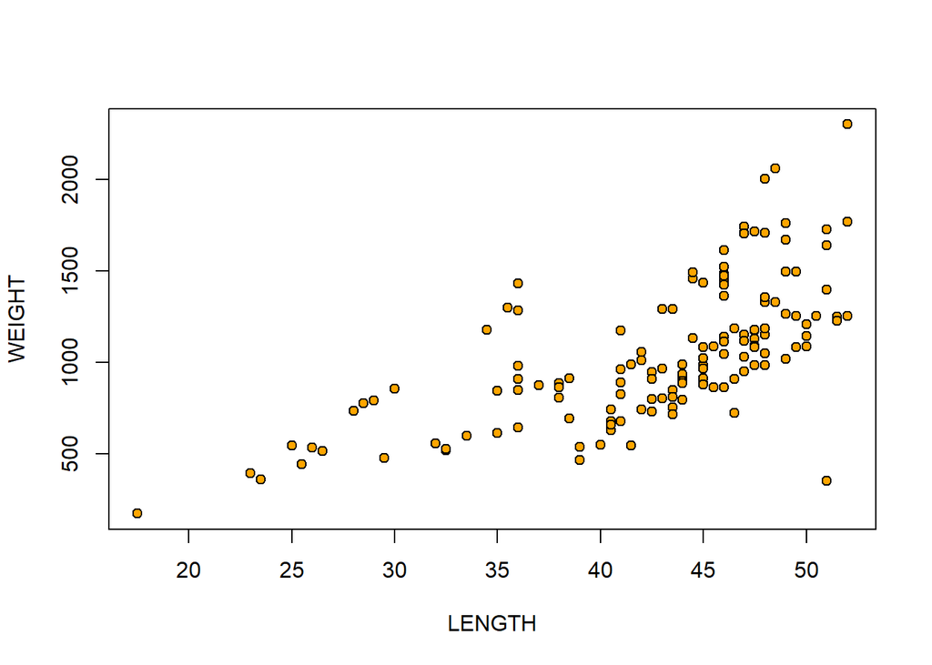

```r
# plot and display both graphs
with(data, plot(WEIGHT ~ LENGTH, bg = "Orange", pch = 21, cex = 1))
```

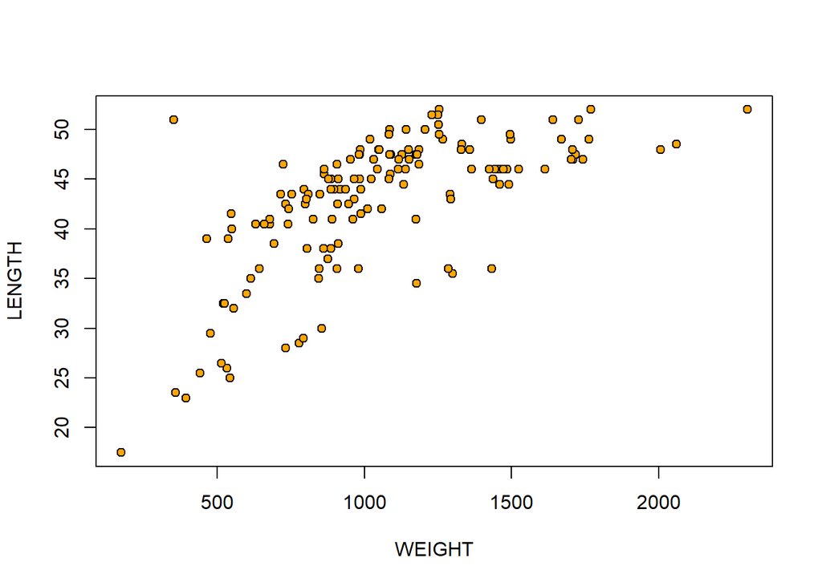

```r
with(data, plot(LENGTH ~ WEIGHT, bg = "Orange", pch = 21, cex = 1))
```

if v = 1:20 what is the last value of v/20?:

```r
# Create a vector with values 1 - 20 stored in it
v = 1:20
# divide each index by 20
v / 20
```

```
##  [1] 0.05 0.10 0.15 0.20 0.25 0.30 0.35 0.40 0.45 0.50 0.55 0.60 0.65 0.70 0.75
## [16] 0.80 0.85 0.90 0.95 1.00
```

```r
# The last value is 1.00 since it would be 20/20
```

## Task 5

Make a table of the rivers:

```r
river_table = with(data,table(data$RIVER))
river_table
```

```
##
## FCM LCM SCM TRM
##   6   6   6 126
```

A colored barplot of rivers:

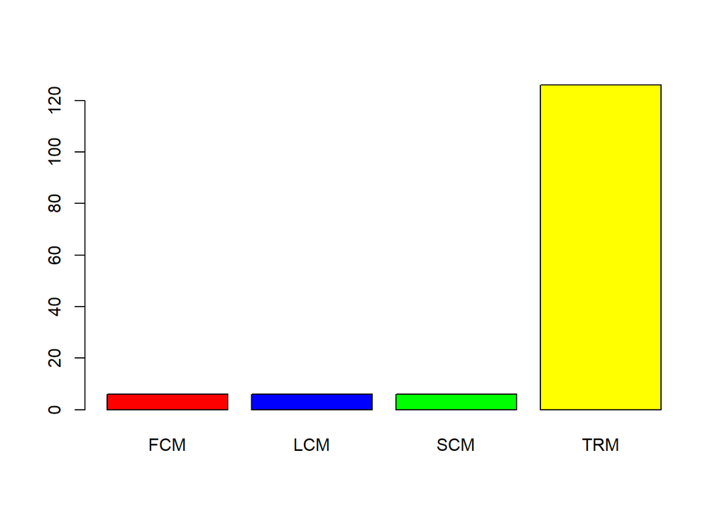

```r
barplot(river_table, col = c("red", "blue", "green", "yellow"))
```

Make a table of river and fish species:

```r
crossed_table_river_fish = with(data, table(data$RIVER, data$SPECIES))
crossed_table_river_fish
```

```
##
##       CCATFISH LMBASS SMBUFFALO
##   FCM        6      0         0
##   LCM        6      0         0
##   SCM        6      0         0
##   TRM       78     12        36
```

Make a barplot of rivers cross with fish species

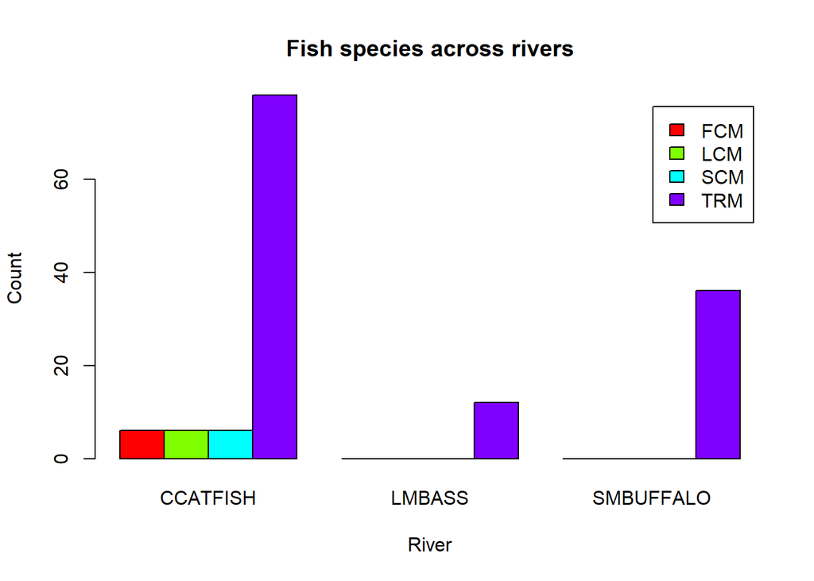

```r
# create a cross table of river and fish species
crossed_table_river_fish <- table(data$RIVER, data$SPECIES)

# make a barplot
barplot(crossed_table_river_fish,
        beside = TRUE,      # put species side-by-side for each river
        col = rainbow(4),
        legend = TRUE,      # add legend for fish species
        xlab = "River",
        ylab = "Count",
        main = "Fish species across rivers")
```

## Task 6

Make a pie chart of fish species:

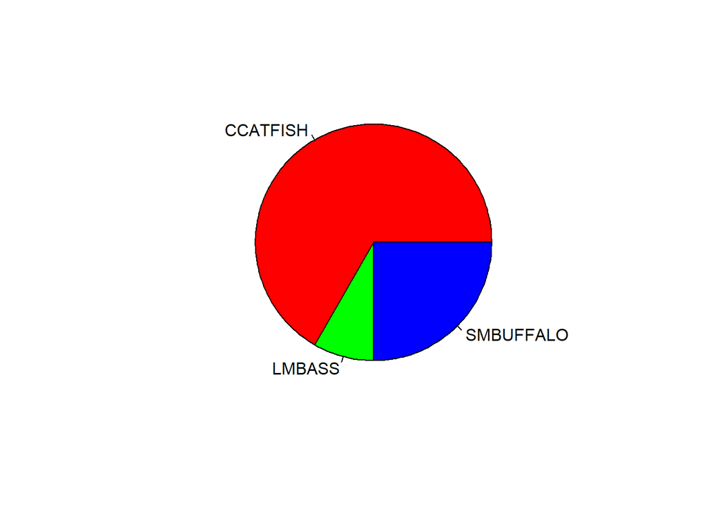

```r
# make the table
species_pie_table <- table(data$SPECIES)

# Display the pie chart
pie(species_pie_table,col = rainbow(3))
```

## Task 7

Box Plots:

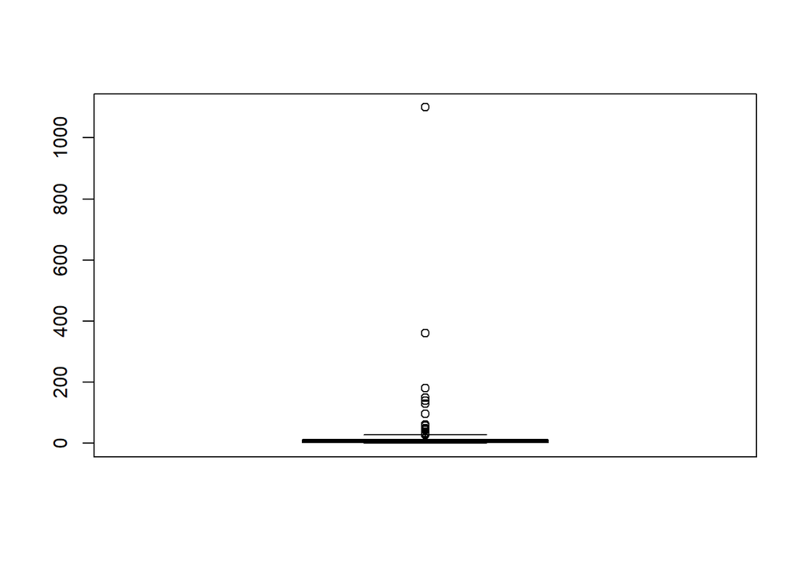

```r
# for DDT
boxplot(data$DDT)
```

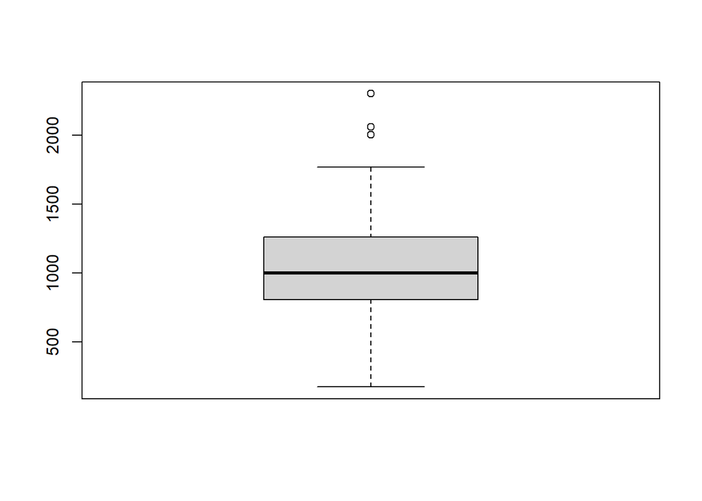

```r
# for weight
boxplot(data$WEIGHT)
```

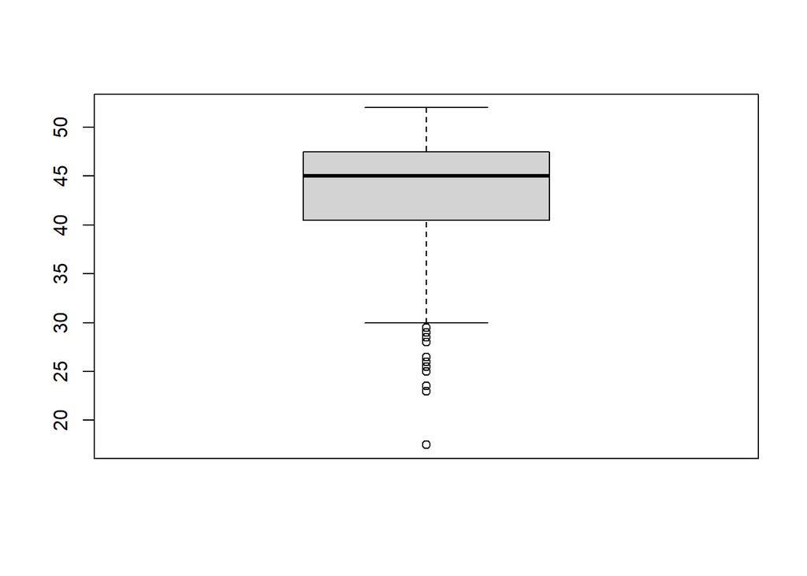

```r
# and for length
boxplot(data$LENGTH)
```

## Task 8

Co plots:

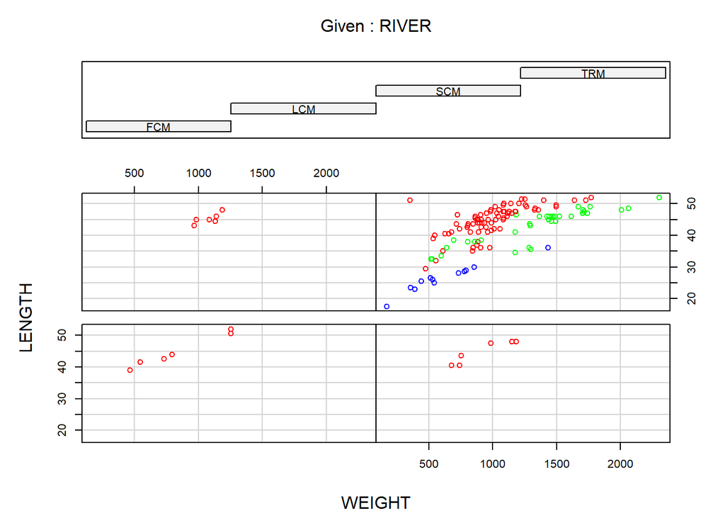

```r
# this first section assigns colors based on species
length_v_weight_coplot = with(data, ifelse(data$SPECIES == "CCATFISH", "red",
                                    ifelse(data$SPECIES == "SMBUFFALO", "green", "blue")))

# plot length on the y axis and weight on the x with sections made for each river
coplot(LENGTH ~ WEIGHT | RIVER, data=data, col=length_v_weight_coplot)
```

Now to coplot with respect to species

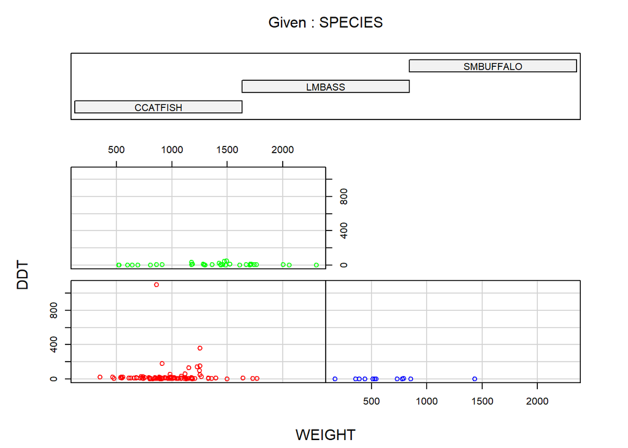

```r
# Now to plot DDT vs Weight given the species
coplot(DDT ~ WEIGHT| SPECIES, data=data, col=length_v_weight_coplot)
```